# U5. La economía política. El pensamiento clásico II. Socialismo

Historia del Pensamiento y del Análisis Económico

Sebastian Freille

Universidad Nacional de Córdoba

# El socialismo científico: Crítica integral de la economía clásica

## Valor de cambio y valor de uso

- Marx excluía el valor de uso de la esfera de investigación de la economía política –no se trata sobre una relación social (“entre las gentes) sino de una relacion entre personas y cosas
  - el valor de cambio si se trata de relaciones entre las gentes
- Robbins argumenta que “el sistema económico como una serie de relaciones interdependientes aunque conceptualmente discretas entre hombres y bienes económicos”

## Valor de cambio y valor de uso (cont.)

- La relación cuantitativa entre cosas que llamamos valor de cambio es, en realidad, sólo una forma exterior de la relación social entre los propietarios de mercancisa –o lo que viene a ser igual en la producción simple de mercancías- entre los productores mismos
- El cambio de mercancías es un cambio de los productos del trabajo de productores individuales
- Distingue entre trabajo útil y trabajo abstracto (“trabajo en general”) –aquel que hace abstracción de toda diferencia en las clases de trabajo cambiado

## Valor de cambio y valor de uso (cont.)

- La relación cuantitativa entre cosas que llamamos valor de cambio es, en realidad, sólo una forma exterior de la relación social entre los propietarios de mercancisa –o lo que viene a ser igual en la producción simple de mercancías- entre los productores mismos
- El cambio de mercancías es un cambio de los productos del trabajo de productores individuales
- Distingue entre trabajo útil y trabajo abstracto (“trabajo en general”) –aquel que hace abstracción de toda diferencia en las clases de trabajo cambiado

## Valor de cambio y valor de uso (cont.)

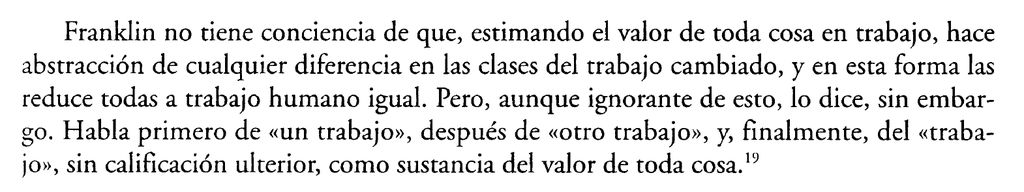

Figura 1: Trabajo abstracto según Marx

## El origen de la plusvalía

- Dijimos antes que el trabajo (fuerza de trabajo) es una **mercancía** –valor de cambio de la mercancía **fuerza de trabajo**
  - La **fuerza de trabajo** es el *trabajador mismo* en un sentido estricto
- Dado que la **fuerza de trabajo** es una mercancía, debe tener un valor como cualquier otra $\longrightarrow$ ¿cómo se determina el valor?
  - el valor de la fuerza de trabajo se reduce al valor de una cantidad más o menos precisa de mercancías ordinarias

## El origen de la plusvalía (cont.)

> El valor de la fuerza de trabajo se determina, como en el caso de cualquier otra mercancía, por el tiempo de trabajo necesario para la producción, y, en consecuencia, también para la reproducción de este artículo especial…Dado el individuo, la producción de fuerza de trabajo consiste en la reproducción de sí mismo o su manutención. Porc consiguiente el tiempo de trabajo requerido para la producción de fuerza de trabajo se reduce al necesario para la producción de los medios de subsistencia; en otras palabras, el valor de la fuerza de trabajo es el valor de los medios de subsistencia necesarios para el mantenimiento del trabajador…Sus medios de susbistencia deben…ser suficientes para mantenerlo en su estado normal como individuo laborante…. **[Mark, Karl, *El Capital*, Tomo I, pp. 189-190]**

## El origen de la plusvalía (cont.)

- ¿Cómo es posible que el capitalista a través del proceso de comprar-producir-vender llegue con $D$ y se retire con $D'$ comprando y vendiendo siempre a los valores de equilibrio?
  - en otras palabras, ¿cómo es posible que se *cree* valor (plusvalía)?
- Plusvalía no puede surgir del proceso de circulación de mercancías $\longrightarrow$ supongamos que todos suben los precios 10%, entonces lo que vendo a un 10% mas, lo termino pagando en forma de insumos a un 10% mas –inflación
- Plusvalía no puede surgir a partir de materiales y/o máquinas que entran en el proceso productivo $\longrightarrow$ materiales y máquinas *pasan* su valor al producto final pero *no aumentan* su valor entre ambas puntas del proceso

## El origen de la plusvalía (cont.)

- Plusvalía sólo puede surgir a partir de la fuerza de trabajo. Vemamos
  1. Capitalista compra la fuerza de trabajo por su valor –salario igual al valor de los medios de subsistencia [i.e. suponga igual a $6 horas$]
  2. Luego de esas 6 horas el trabajador ha añadido ese equivalente al valor de la mercancía (más las horas de trabajao contenidas en materiales y maquinaria)
  3. Si la jornada de trabajo fuera de 12 horas, durante las ultimas 6 horas el obrero continúa agregando valor pero es un valor *en exceso del necesario para compensar sus medios de subsistencia*
- En resumen **es una plusvalía que el capitalista toma para si**

## El origen de la plusvalía (cont.)

> Todas las condiciones del problema se cumplen, en tanto que las leyes que regulan el cambio de mercancías no han sido en ninguna forma violadas. Pues el capitalista como comprador pagó por cada mercancía, por el algodón, por el huso y por la fuerza de trabajo, su valor completo. Vende su hilaza…en su valor exacto. Sin embargo, retira…de la circulación más de lo que originalmente lanzó a ella **[Mark, Karl, *El Capital*, Tomo I, pp. 217]**

## El origen de la plusvalía (cont.)

- Con el trabajo de 1 (un) día, el trabajador *produce más* que los medios de susbsistencia de un día
- La *jornada de trabajo* puede pues dividirse en 2 (dos)
  1. trabajo necesario $\longrightarrow$ producto de este trabajo va al trabajador como salario
  2. trabajo excedente $\longrightarrow$ producto de este trabaja va para el capitalista como *plusvalía*
- El trabajo necesario y el trabajo excedente surgen en toda sociedad que en que la productividad del trabajo humano se ha elevado por encima de cierto mínimo muy bajo -i.e. todas excepto las más primitivas

## El origen de la plusvalía (cont.)

> Lo específico del capitalismo no es *el hecho* de la explotación de una parte de la población por otra, sino *la forma* que adopta esta explotación, es decir, la *producción de plusvalía*

## Los componentes del valor

- El **valor de toda mercancía** producida en la economía capitalista puede divirse en 3 (tres) partes
  1. Valor de materiales y maquinaria usados $\longrightarrow$ **capital constante, $c$**
  2. Valor de la fuerza de trabajo $\longrightarrow$ **capital variable, $v$**
  3. Excedente producido por la fuerza de trabajo $\longrightarrow$ **plusvalía, $p$**
     $$\begin{equation}
     c+v+p=valor \quad total
     \end{equation}$$

## Los componentes del valor (cont.)

- Un comentarios relevante
  - Esta fórmula refleja en mayor o menor medida (aunque simplificada) los balances de las empresas modernas –valor total equivale a ventas brutas; $c$ es materiales/insumos mas depreciacion; $v$ son sueldos y salarios; y $p$ ingreso disponible para distribuir como intereses/dividendos/beneficio (o reinvertir

## Los componentes del valor (cont.)

- Define la **tasa de plusvalía** como la proporción de plusvalía respecto al capital variable
  $$\begin{equation}
  \frac{p}{v}=p'
  \end{equation}$$
- Con el ejemplo anterior de jornada de 12 (doce) horas, la tasa de plusvalía es igual a 100%
- Puede ser expresada en horas de trabajo como en valores –sólo hace falta valorizar monetariamente el producido de una hora de trabajo.
- La tasa de plusvalía depende de 3 factores: a) duración de jornada;
  2. cantidad de mercancías que entran en el salario real; c) productividad del trabajo

## Los componentes del valor (cont.)

- La tasa de plusvalía aumenta:
  - con un aumento en la duración de la jornada de trabajo
  - con una disminución del salario real
  - con un aumento en la productividad del trabajo
- Marx frecuentemente suponía que la tasa de plusvalía era igual en todas las ramas de la industria y en todas las empresas hacia adentro de cada industria
  - decía que la movilidad del trabajo iba a eliminar diferencias significativas de tasas de plusvalía

## Los componentes del valor (cont.)

- También define la **composición orgánica del capital** como la proporción entre el capital constante y el capital total:
  $$\begin{equation}
  \frac{c}{c+v}=o
  \end{equation}$$
- La **COK** no es otra cosa que una medida de la amplitud/extensión en que el trabajo es provisto de maquinas e insumos en el proceso productivo

## Los componentes del valor (cont.)

- Finalmente define la **tasa de ganancia** como la proporción de plusvalía con respecto al desembolso total del capital:
  $$\begin{equation}
  \frac{p}{c+v}=g
  \end{equation}$$
- Estrictamente esto muestra la tasa de ganancia (rentabilidad) sobre el capital realmente empleado en la producción de una mercancía
  - note aquí que capital realmente empleado (durante un año) no es lo mismo que inversión total (durante un período más largo)

## Los componentes del valor (cont.)

- Recordando que $p'=\frac{p}{v}$, $o=\frac{c}{c+v}$ y $g=\frac{p}{c+v}$ se sigue que:
  $$\begin{equation}
  g=p'(1-o)
  \end{equation}$$
- Esto es, la **tasa de ganancia**, como la variable más importante a mirar por el capitalista, depende en forma clave de las dos variables más fundamental del análisis marxista, la *tasa de plusvalía* y la *composición orgánica del capital*
- También supuso que la tasa de ganancia era uniforme a nivel de industria y de empresas –por movilidad tanto de $L$ como de $K$ [suponía técnicas iguales en todos lados]

## Los componentes del valor (cont.)

> **El problema de la transformación.** Si la **tasa de plusvalía** y la **tasa de ganancia** son iguales en todos lados, si el *cambio de las mercancias* debe hacerse de acuerdo a la *ley del valor*, entonces se sigue que la **COK debe ser igual en todos lados**. Si el **valor de la mercancía A** se forma $10c+20v+20p=50$ y el **valor de la mercancía B** se forma $30c+10v+10p=50$, en ambos casos la tasa de plusvalía es la misma (100%) y ambos bienes deberían cambiarse 1 a 1. Pero si ocurre esto, el capitalista de A tendría una $g=66,66%$ y el capitalista de B una $g=25%$. Esto no sería sostenible ni estable. Tampoco son iguales las COK.
- En los dos primeros volúmenes de El Capital ignoró diferencias en la COK (no existían para el); en el tercer volumen “se retracta” y ofrece como respuesta el problema de la transformación

## El caracter histórico del pensamiento de Marx

- Existe algo de ironía, sin embargo, en que muchos autores destacan que el método de Marx es en profunda esencia histórico.
  - para Marx la realidad social es un proceso histórico, proceso que no conoce finalidad ni estaciones de parada
- Este proceso de cambio social no es sin embargo meramente mecánico $\longrightarrow$ es producto de la acción humana pero limitada por la clase de sociedad en que se desarrolla
- En este sentido, el capitalismo como sistema tiene caracter histórico específico (y transitorio)
  - crítica de Marx a no marxistas que dan capitalismo por sentado como se da por sentado el sistema solar
- Note que muchos autores del pasado (no JS Mill) aplicaban caracter transitorio a sistemas pasados pero no al capitalismo

## El problema del valor cualitativo

- Marx parte del estudio de las mercancías y por ende el estudio de la relación económica del cambio. Analiza en primer lugar, la producción simple de mercancías –cambio elemental, economía no industrial
- Para Smith el cambio está vinculado inseparablemente de la división del trabajo –el cambio, en efecto, es anterior a la división del trabajo (y causa de esta!)
- Marx no quita importancia a la división del trabajo pero rechaza que la producción de mercancías sea una condición necesaria para la división del trabajo!

## El problema del valor cualitativo (cont.)

- De esta manera, la producción de mercancías *no es la forma universal e inevitable de la vida económica* –es más bien una de las formas posibles pero que de ninguna manera puede considerarse como manifestación directa de la naturaleza humana
- Acá Marx marca un contraste rotundo –la producción de mercancías es separada de fenómenos naturales y por ende debe ser estudiada la naturaleza de las relaciones sociales subyacentes
- La economía no sólo debe preocuparse por el valor de cambio en tanto relación cuantitativa entre productos sino también en tanto relación cualitativa y específica entre productores

## El problema del valor cualitativo (cont.)

- En palabras de Petty, Marx se propone analizar tanto el problema del valor cuantitativo y el problema del valor cualitativo
- La teoría del valor de Marx es original y desafiante para el status quo $\longrightarrow$ es conveniente dividir su análisis en dos partes
  - teoría del valor cualitativo de uso
  - teoría del valor cualitativo de cambio
- Más adelante discutiremos la teoría del valor cuantitativo

## Teoría del valor de uso (cualitativo)

> Toda mercancía tiene un doble aspecto, el de valor de uso y el de valor de cambio

## Teoría del valor de uso (cualitativo) (cont.)

- El valor de uso no da a una mercancía ningún carácter peculiar $\longrightarrow$ expresa cierta relación entre el consumidor y el objeto consumido
- Pero para Marx la economía política es una “ciencia de las relaciones entre las gentes”, por lo cual no ahondó en esto
  - note como nuevamente su método es relevante; nunca siquiera consideró el valor de uso por cuanto no implica una relación social
- Esto sería totalmente abandonado y dejado de lado, al menos desde los escritos de Robbins
  - algunos critican que Marx no desarrolló una teoría subjetiva del valor

## Teoría del valor de cambio (cualitativo)

- Marx decía que sólo en calidad de mercancías las cosas tienen valor de cambio. ¿Y la relación social aquí donde esta?
- La relación cuantitativa de cambio es sólo una forma *exterior de la relación social* entre los propietarios de mercancías
  - en otras palabras, esta relacion de cambio es una expresión del hecho de que los productores individuales *trabajan los unos para los otros*
- En lingo marxista, el cambio de mercancías es un cambio en los productos del trabajo de productores individuales
  - hecho de que las mercancías son productos del trabajo humano en una sociedad basada en la división del trabajo

## Teoría del valor de cambio (cualitativo) (cont.)

> Es imprescindible entender que fue el análisis de las características sociales de la producción de mercancías lo que llevó a Marx a identificar el trabajo como la sustancia del valor
- Como **valor de uso, una mercancía es un rasgo universal de la existencia humana**, presente en todas y cada una de las formas de sociedad
- En cambio **como valor de cambio es un rasgo de una forma histórica específica de sociedad** distinguida por 2 características centrales: 1) división del trabajo; 2) producción privada.

## Trabajo y valor

- Si todas las categorías económicas representan relaciones sociales, entonces el trabajo representa el valor que yace oculto detrás del valor de cambio
- Una propiedad de la mercancía como portadora y expresión de relaciones sociales es su propiedad como *producto del trabajo*, como actividad humana materializada
- El trabajo para Marx tiene dos aspectos
  - uno correspondiente al valor de uso
  - otro correspondiente al valor de la mercancía

## Trabajo y valor (cont.)

- A la mercancía como valor de uso, corresponde el trabajo como **trabajo útil**
  - el trabajo útil no era la unica fuente del valor de uso; también lo era la naturaleza (tierra). De ahí que destaca a Petty.
- A la mercancía como valor, corresponde el trabajo como **trabajo abstracto**
  - si nos abstraemos del valor de uso, la actividad productiva no es más que el gasto de fuerza humana de trabajo. En este sentido, el valor de una mercancía representa trabajo humano *abstracto*

## Trabajo y valor (cont.)

> Por una parte, todo trabajo es, hablando fisiológicamente, un gasto de fuerza humana de trabajo, y en su carácter de trabajo humano abstracto idéntico, crea y forma los valores de las mercancías . Por otra parte, todo trabajo es el gasto de fuerza humana de trabajo en una forma especial y con un fin preciso, y en este, su carácter de trabajo útil concreto, produce valores de uso

## Trabajo abstracto

- En forma simple podríamos decir que trabajo abstracto es en cierta forma, “trabajo en general”, trabajo liso y llano, no específico, ni distinguible en términos de tareas de diferentes trabajos
- Es una forma importante de encontrar una suerte de *numeraire*, de elemento al que puede reducirse todo a una denominador común $\longrightarrow$ “el trabajo”
- No era capricho de Marx referirse a esta suerte de trabajo abstracto $\longrightarrow$ el modo y la esencia de producción capitalista es perefectamente compatible con esta idea (movilidad de trabajo)

## Relación entre cualitativo y cuantitativo

- A primera vista una mercancía (zapato) parece ser simplemente un artículo útil que ha sido producida por una clase especial de trabajador (zapatero) en un modo de producción simple.
- Pero en una segunda mirada esta mercancía tiene en común con otras mercancías (todas) el hecho de absorber parte de la fuerza de trabajo disponible en una sociedad (trabajo abstracto materializado)
- Es esta última característica la que da sentido a la mercancía como punto de partido del análisis marxista

## Relación entre cualitativo y cuantitativo (cont.)

- Para la ortodoxia clásica, la teoría del valor sólo implicaba descubrir las leyes que rigen las proporciones relativas en las que las mercancías se cambian unas por otras (sólo un tema de valor de cambio)
- Pero para Marx, si el trabajo abstracto materializado es *medible* en terminos de unidades de tiempo, se hace presente la significación del valor como categoría cuantitativa diferente del valor de cambio [IMPORTANTE]
- La tarea central de la teoría del valor cuantitativo surge de esta definición del valor como magnitud

## Relación entre cualitativo y cuantitativo (cont.)

> La magnitud del valor expresa…la conexión que existe entre cierto artículo y la parte del tiempo total de trabajo de la sociedad que se requiere para producirlo
- En otras palabras la teoría del valor cuantitativo debe averiguar las leyes que gobiernan la asignación de la fuerza de trabajo a las diferentes esferas de la producción en una sociedad de productores de mercancías
- Importante reconocer que *trabajo abstracto* refiere a la teoría del valor cualitativo; mientras que *trabajo socialmente necesario* a la teoría del valor cuantitativo

## El fetichismo de la mercancía

- La teoría del valor cualitativo de Marx tiene su corolario en la doctrina del fetichismo de la mercancía. Por ella Marx refiere a que en la producción de mercancías la relación básica entre los hombres “adopta a sus ojos, la fantástica forma de una relación entre las cosas”
- Esto implica una **materialización de las relaciones sociales**. Según Marx esto no sucedía en sociedades pre-capitalistas donde las relaciones de producción tenían un carácter personal directo
- Es una situación en que “el proceso de producción tiene dominio sobre el hombre en lugar de ser controlado por él”

## El fetichismo de la mercancía (cont.)

> Desde la economía clásica y salvo con la posible excepción de JS Mill, los autores no se habían preocupado más alla de ofrecer una concepción racional de las relaciones de producción capitalistas. Es con algunos de los primeros sociales y con Marx fundamentalmente que trataron de descubrir las relaciones sociales reales subyacentes en en las formas de producción de las mercancías. En el capitalismo cada quien aparece como vendedor de alguna mercancía de la que es propietario; como propietarios de mercancías están en un plano de igualdad perfecta pero no advierten frecuentemente que el trabajo de uno se dicta en condiciones que otro dispone; en consecuencia, no advierte que está siendo sujeto de explotación

## El capitalismo

> **Bajo la producción simple de mercancías** cada productor posee y trabaja con sus propios medios de producción. **Bajo el capitalismo** la propiedad de los medios de producción corresponde a un conjunto de individuos mientras que otro conjunto de individuos realiza el trabajo.

> Los medios de producción como la fuerza de trabajo son **mercancías** en si mismas; es decir son objetos de cambio y por tanto portan valor de cambio. En otras palabras, no sólo las relaciones entre propietarios sino también las relaciones entre propietarios y no propietarios tienen carácter de relaciones de cambio

## El capitalismo (cont.)

- Lo primero es característico de la producción de mercancías en general (relaciones de cambio entre propietarios)
- Lo segundo es característico de la producción de mercancías en el capitalismo solamente

> La compra y venta de la fuerza de trabajo es para Marx la diferencia específica del capitalismo